# CS 5324 Lab 5: Wide and Deep Networks

## Graduate Analysis

### Embedded Weights and Dimension Reduction

```python
for layer in model1.layers:
    weights = layer.get_weights() # list of numpy arrays
print(weights)
```

```
[array([[ 0.16144598],
       [ 0.55564344],
       [-0.6429667 ],
       [-0.41011062],
       [ 0.37071282],
       [ 0.47900093],
       [-0.5132408 ],
       [ 0.6869473 ],
       [ 0.4899911 ],
       [ 0.5196462 ],
       [-0.65306395],
       [ 0.60444415],
       [-0.7383649 ]], dtype=float32), array([0.0274857], dtype=float32)]
```

```python
from sklearn.decomposition import PCA

pca = PCA(n_components=2)
pca.fit(X) # fit data and then transform it
X_pca = pca.transform(X)
```

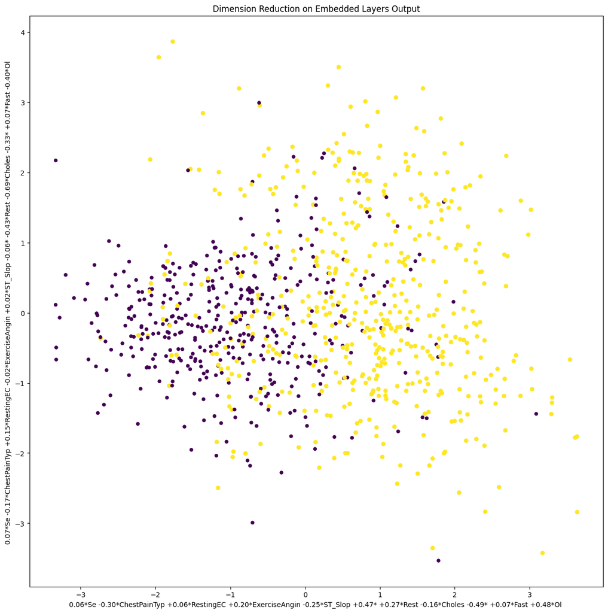

```python
cmap = sns.set(style="darkgrid")
def get_feature_names_from_weights(weights, names):
    tmp_array = []
    for comp in weights:
        tmp_string = ''
        for fidx,f in enumerate(names):
            if fidx>0 and comp[fidx]>=0:
                tmp_string+='+'
            tmp_string += '%.2f*%s ' % (comp[fidx],f[:-5])
        tmp_array.append(tmp_string)
    return tmp_array

plt.style.use('default')
pca_weight_strings = get_feature_names_from_weights(pca.components_, feature_columns)

# create some pandas dataframes from the transformed outputs
df_pca = pd.DataFrame(X_pca,columns=[pca_weight_strings])

from matplotlib.pyplot import scatter

# scatter plot the output, with the names created from the weights
plt.figure(figsize=(15,15))
plt.xlabel(pca_weight_strings[0])
plt.ylabel(pca_weight_strings[1])

plt.title("Dimension Reduction on Embedded Layers Output")

ax = scatter(X_pca[:,0], X_pca[:,1], c=y, s=(y+2)*10, cmap=cmap)
```

The above scatterplot shows two different colors (for the two classes in our target feature). The intersection of these plot points highlights how some of the features in this dataset can greatly influence whether a patient is at risk of heart failure (*class 1*) or not (*class 0*). Due to the close intersection of most plot points, we can say that most of the features in this dataset are important when considering how well any model can predict heart failure using this dataset.

### ROC Curve

An ROC (Receiver Operating Charcateristic) Curve is a type of graph that shows the performance of a model at all classification threshholds between the True Positive rate (recall) and False Positive Rate.

The AUC (Area Under the Curve) provides an aggregate visual of the performance across the classification thresholds. The AUC is measured from a range of 0-1, and the more accurate our model is, the closer to 1.0 its AUC value is.

Code used in this notebook was adapted from Professor Larson's notebooks for this class.  
We appreciate Professor Larson's models.

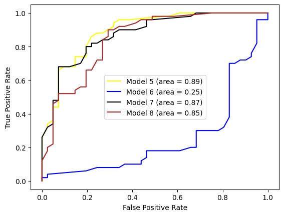

```python
from sklearn.metrics import roc_curve, auc
plt.figure()

y_pred = model5.predict([X_test_crossed,X_test_cat,X_test_num])
fpr, tpr, thresholds =  roc_curve(y_test.flatten(), y_pred)
roc_auc = auc(fpr, tpr)
plt.plot(fpr, tpr, color='yellow', label='Model 5 (area = %0.2f)' % roc_auc)

y_pred = model6.predict([X_test_crossed,X_test_cat,X_test_num])
fpr, tpr, thresholds =  roc_curve(y_test.flatten(), y_pred)
roc_auc = auc(fpr, tpr)
plt.plot(fpr, tpr, color='blue', label='Model 6 (area = %0.2f)' % roc_auc)

y_pred = model7.predict([X_test_crossed,X_test_cat,X_test_num])
fpr, tpr, thresholds = roc_curve(y_test.flatten(), y_pred)
roc_auc = auc(fpr, tpr)
plt.plot(fpr, tpr, color='black', label='Model 7 (area = %0.2f)' % roc_auc)

y_pred = model8.predict([X_test_crossed,X_test_cat,X_test_num])
fpr, tpr, thresholds = roc_curve(y_test.flatten(), y_pred)
roc_auc = auc(fpr, tpr)
plt.plot(fpr, tpr, color='Brown', label='Model 8 (area = %0.2f)' % roc_auc)
plt.ylabel('True Positive Rate')
plt.xlabel('False Positive Rate')
plt.legend()
```

We expected model 8 to perform the best due to having an extensive deep and wide branch. However, it is clear that model 5 is the best performing model.

Code used in this notebook was adapted from Professor Larson's notebooks for this class.  
We appreciate Professor Larson's models.